# Презентация по разделу №1 Безопасность в сети внешнего курса на тему Основы кибербезопасности

Основы информационной безопасности

Татьяна Александровна Пономарева

Российский университет дружбы народов

2026-04-28

# Информация

## Докладчик

*Пономарева Татьяна Александровна* Студент группы НКАбд-04-24 *Российский университет дружбы народов им. П. Лумумбы* taponomareva6742@gmail.com *https://github.com/taponomareva

# Вводная часть

## Цель работы

Выполнить задания раздела 1 и понять, что из себя представляет безопасность в сети.

## Теоретическое введение

Данный курс рассчитан на любого пользователя ПК/смартфона/банкомата и состоит из 3-х разделов, также он содержит лекции, материалы для доп. чтения и тесты [1].

# Выполнение заданий раздела 1 “Безопасность в сети”

## Как работает интернет: базовые сетевые протоколы. Протокол прикладного уровня

Протокол прикладного уровня - HTTPS (рис. 1).

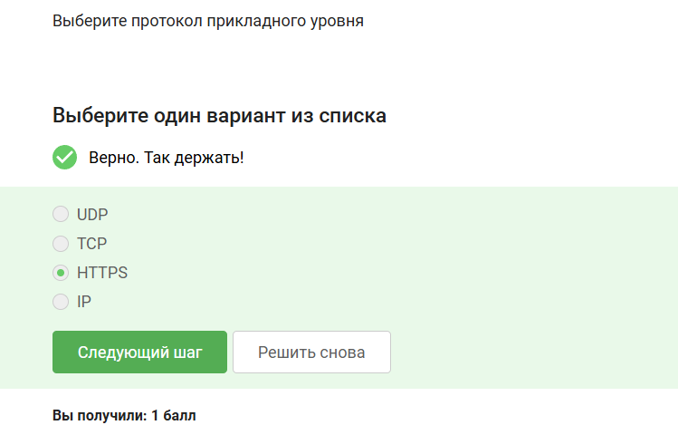

Рисунок 1: Протокол прикладного уровня

## Уровень протокола ТСР

Протокол ТСР работает на транспортном уровне (рис. 2).

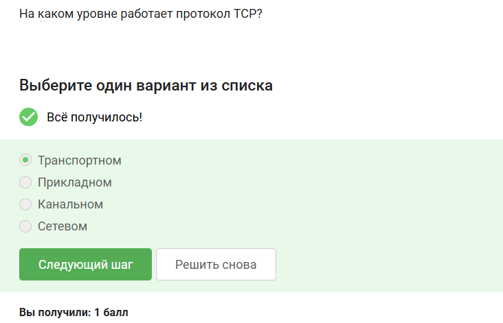

Рисунок 2: Уровень протокола ТСР

## Корректные адреса IPv4

Корректные адреса IPv4 - это те, которые соответствуют правилам составления адреса, т е 90.11.90.22 и 25.198.0.15. Остальные не подходят, т к число, стоящее в составе адреса, не может превышать 255 (рис. 3).

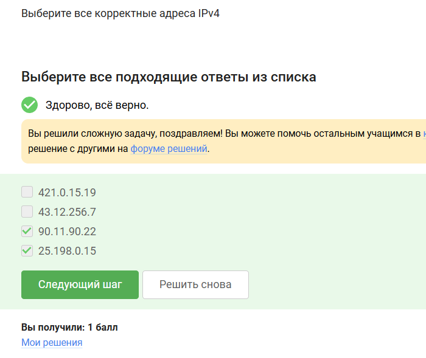

Рисунок 3: Корректные адреса IPv4

## Функция DNS сервера

DNS сервер сопоставляет IP адреса доменным именам (рис. 4).

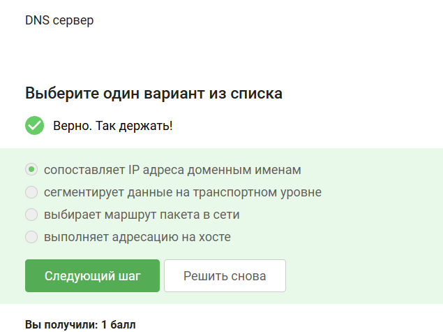

Рисунок 4: Функция DNS сервера

## Последовательность протоколов в модели TCP/IP

Корректная последовательность протоколов в модели TCP/IP:прикладной - транспортный - сетевой - канальный (рис. 5).

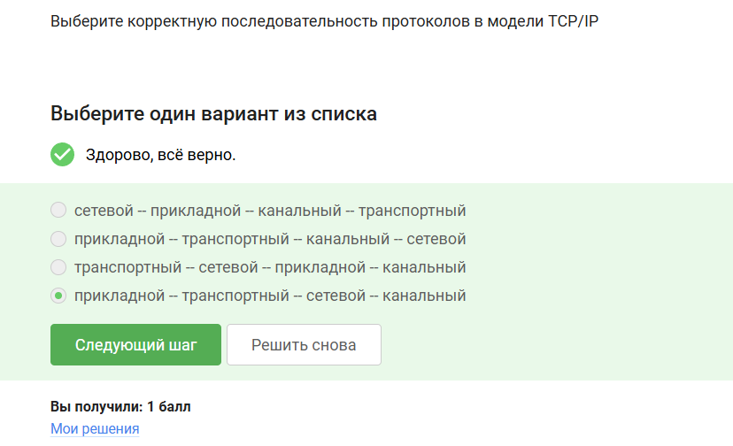

Рисунок 5: Последовательность протоколов в модели TCP/IP

## Функция протокола http

Протокол http предполагает передачу данных между клиентом и сервером в открытом виде, т к в конце не стоит s (рис. 6).

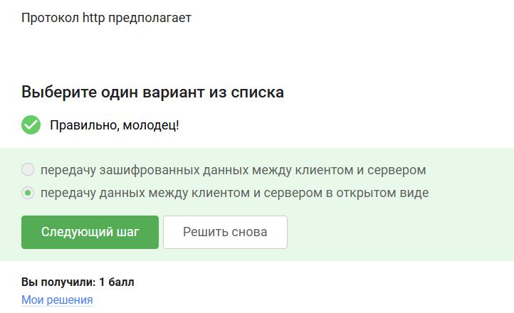

Рисунок 6: Функция протокола http

## Состав протокола https

Протокол https состоит из двух фаз: рукопожатия и передачи данных (рис. 7).

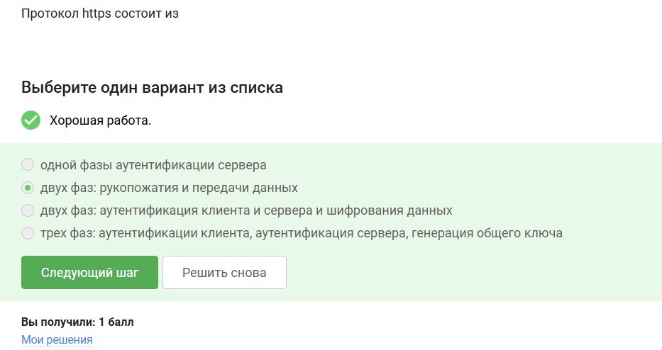

Рисунок 7: Состав протокола https

## Определение версии протокола TLS

Версия протокола TLS определяется и клиентом, и сервером в процессе “переговоров” (рис. 8).

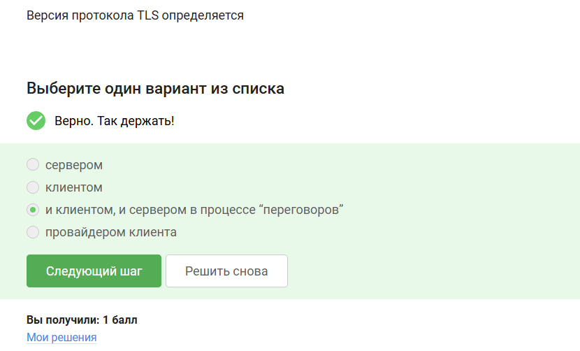

Рисунок 8: Определение версии протокола TLS

## Отсутствие шифрования данных в фазе “рукопожатия” протокола TLS

В фазе “рукопожатия” протокола TLS не предусмотрено шифрование данных (рис. 9).

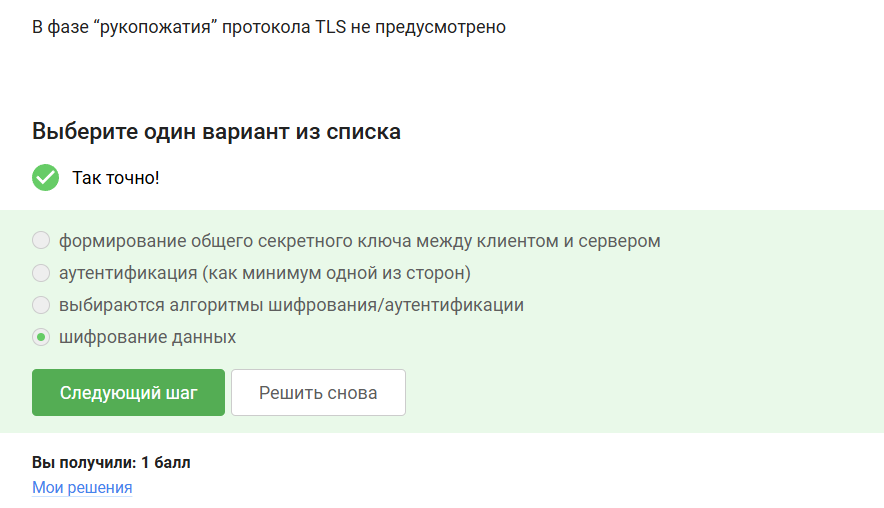

Рисунок 9: Отсутствие шифрования данных в фазе “рукопожатия” протокола TLS

## Персонализация сети. Состав куки

Куки хранят: id сессии и идентификатор пользователя (рис. 10).

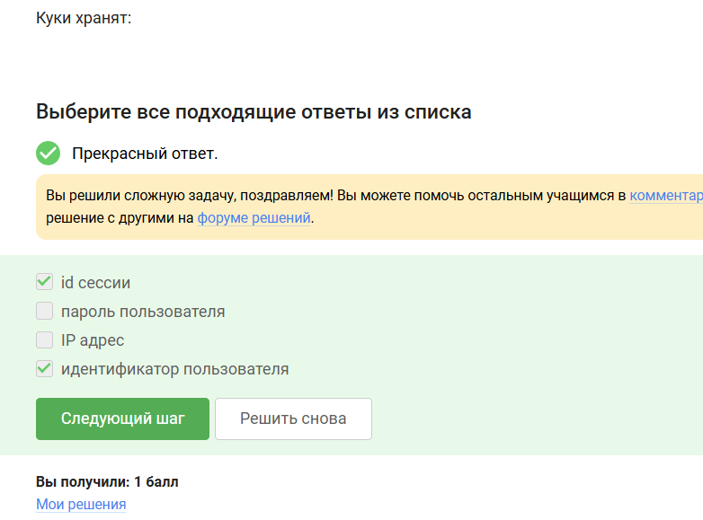

Рисунок 10: Персонализация сети. Состав куки

## Неиспользование куки

Куки не используются для улучшения надежности соединения (рис. 11).

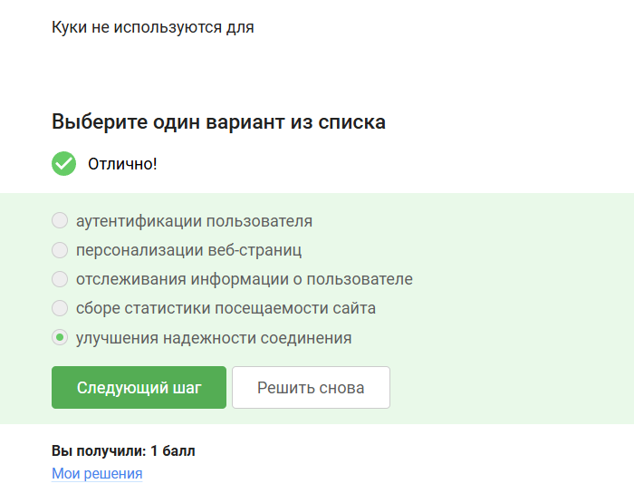

Рисунок 11: Неиспользование куки

## Генерация куки

Куки генерируются сервером, а не клиентом (рис. 12).

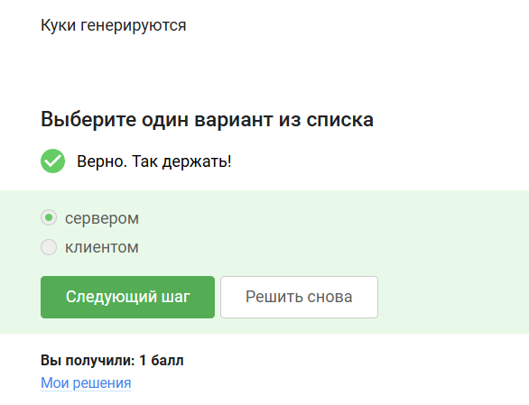

Рисунок 12: Генерация куки

## Хранение куки

Сессионные куки хранятся в браузере на время пользования сайтом (рис. 13).

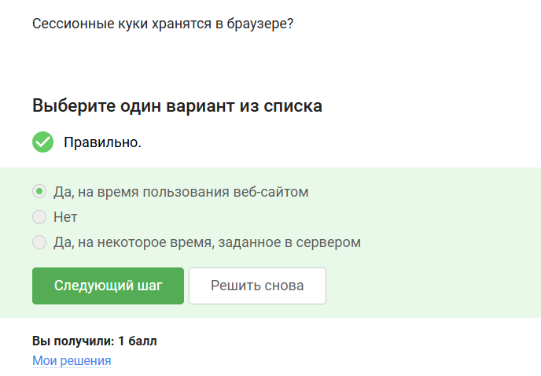

Рисунок 13: Хранение куки

## Браузер TOR. Анонимизация. Количество узлов в сети TOR

В луковой сети TOR находится 3 промежуточных узла (рис. 14).

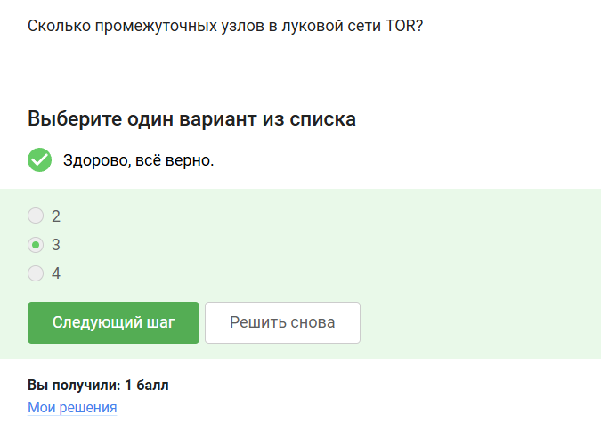

Рисунок 14: Количество узлов в сети TOR

## Доступ к IP-адресу получателя

IP-адрес получателя известен отправителю и выходному узлу (рис. 15).

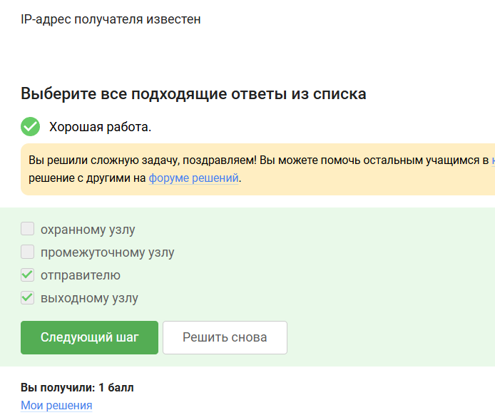

Рисунок 15: Доступ к IP-адресу получателя

## Генерация общего секретного ключа и доступ к нему

Отправитель генерирует общий секретный ключ с охранным, промежуточным и выходным узлом (рис. 16).

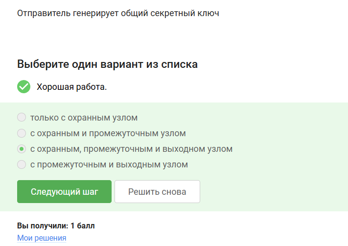

Рисунок 16: Генерация общего секретного ключа и доступ к нему

## Браузер TOR не является необходимым

Пользователь не должен использовать браузер TOR для успешного получения пакетов (рис. 17).

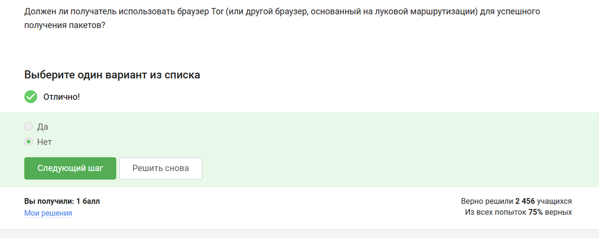

Рисунок 17: Браузер TOR не является необходимым

## Беспроводные сети Wi-fi. Определение Wi-fi

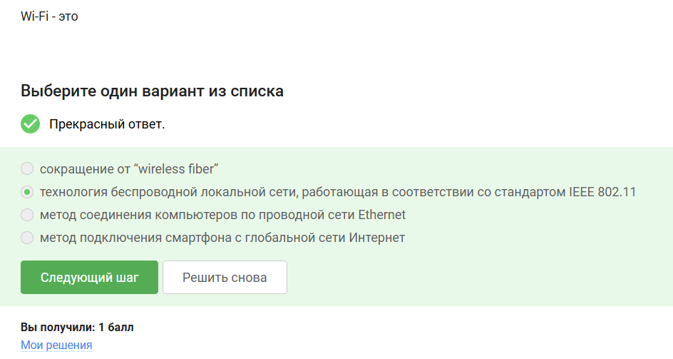

Рисунок 18: Определение Wi-fi

## Уровень работы протокола Wi-fi

Протокол Wi-fi работает на канальном уровне (рис. 19).

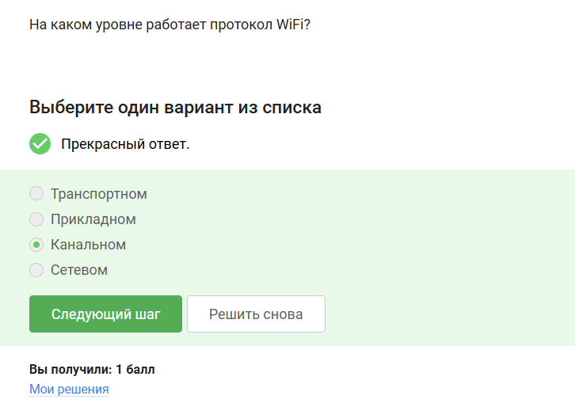

Рисунок 19: Уровень работы протокола Wi-fi

## Небезопасный метод обеспечения шифрования и аутентификации в сети Wi-Fi

WEP - небезопасный метод обеспечения шифрования и аутентификации в сети Wi-Fi (рис. 20).

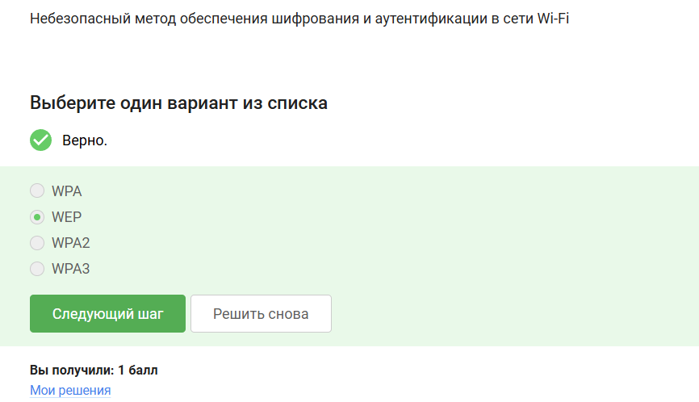

Рисунок 20: Небезопасный метод обеспечения шифрования и аутентификации в сети Wi-Fi

## Передача данных между хостом сети и роутером

Данные между хостом сети (компьютером и смартфоном) и роутером передаются в зашифрованном виде после аутентификации устройства (рис. 21).

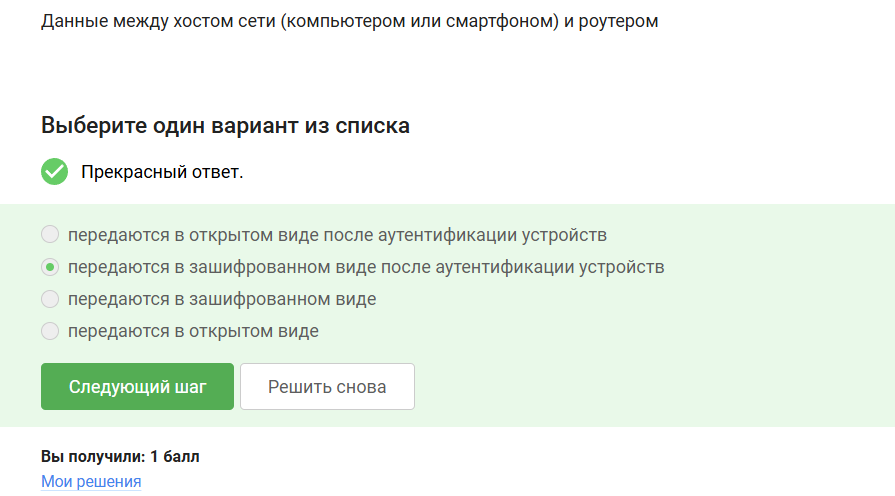

Рисунок 21: Передача данных между хостом сети и роутером

## Метод WPA2 Personal

Для домашней сети для аутентификации обычно используется метод WPA2 Personal (рис. 22).

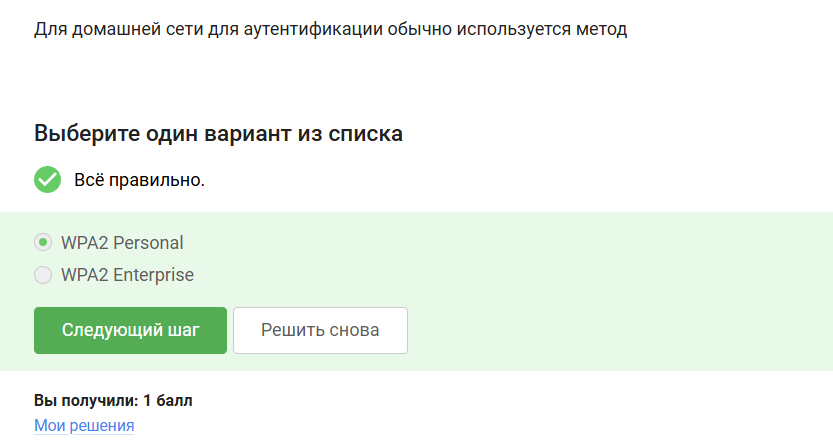

Рисунок 22: Метод WPA2 Personal

# Выводы

В ходе прохождения раздела 1 внешнего курса были выполнены задания раздела 1 и была изучена характеристика безопасности в сети.

# Список литературы

1. И. Канта Б. им. Основы кибербезопасности: Внешний курс на платформе Stepik [Электронный ресурс]. Платформа Stepik. URL: https://stepik.org/111512 (дата обращения: 28.04.2026).